[figure not shown]

# Implementing a Neural Network from Scratch Using NumPy

Published on February 25, 2022

# Table of Contents

I have implemented forward/back propagation functions using Python/Numpy and compared with PyTorch implementation. I have also implemented all functions **vectorized** (e.g. used `np.einsum` for implementing `torch.bmm`) on the Python/Numpy side.

This notebook doesn't include much comments. Instead, it is mostly about math formulas and their different implementations. If you are here to learn how things work then you are in the wrong place. Go here instead: [Coursera: Deep Learning Specialization - Course 1](https://www.youtube.com/watch?v=CS4cs9xVecg&list=PLkDaE6sCZn6Ec-XTbcX1uRg2_u4xOEky0)

If you curious about the implementation then we can continue. Before starting reading this notebook, make sure that you know about Numpy a bit and studied Back-propagation learning method (can be found in Deep Learning Specialization). Also, if you are not familiar with PyTorch its usage may look difficult at first. For example, summing two Tensors via `c = a + b` not just computing the output but also building a `Computation Graph` (This is also mentioned in the Specialization). This makes Back-propagation easier with PyTorch.

See:

- https://numpy.org/doc/stable/user/basics.broadcasting.html
- https://numpy.org/devdocs/user/absolute_beginners.html
- https://pytorch.org/tutorials/beginner/basics/intro.html
- https://pytorch.org/tutorials/beginner/basics/autogradqs_tutorial.html

Note: Understanding the implementation of `softmax_derivative` may require very good Numpy knowledge. Don't worry if you are a beginner.

Good luck :)

## Import Libraries

```python
import platform
import os, random, time
import numpy as np
import torch
import torch.nn as nn
import torchvision
import torchvision.transforms as transforms
import torchvision.datasets as datasets
import matplotlib
import matplotlib.pyplot as plt
%matplotlib inline

print("Python:", platform.python_version())
print("Numpy:", np.__version__)
print("Matplotlib:", matplotlib.__version__)
print("PyTorch:", torch.__version__)
print("TorchVision:", torchvision.__version__)
```

```
Python: 3.9.6
Numpy: 1.20.3
Matplotlib: 3.4.2
PyTorch: 1.10.0.dev20210814
TorchVision: 0.11.0.dev20210814
```

## Implementation

### Function: Softmax

$$ \text{softmax}(z_i) = \frac{\exp(z_i)}{\sum_j \exp(z_j)} $$

```python
# softmax(logits) = Sz
# logits.shape = Sz.shape = (samples, features)
def softmax(logits):
    logits = logits - np.max(logits, axis=1, keepdims=True) # optional: make softmax numerically stable
    exps = np.exp(logits)
    return exps / np.sum(exps, axis=1, keepdims=True)
```

```python
x = np.random.random((2,3))

# test numpy way
Sz1 = softmax(x)
print("softmax() result:\n", Sz1)

# test pytorch way
Sz2 = torch.nn.functional.softmax(torch.Tensor(x), dim=1).numpy()
print("\ntorch.nn.functional.softmax() result:\n", Sz2)
```

```
softmax() result:
 [[0.37455336 0.25244407 0.37300257]
 [0.28690064 0.23887557 0.47422379]]

torch.nn.functional.softmax() result:
 [[0.37455335 0.25244406 0.37300256]
 [0.28690067 0.23887558 0.4742238 ]]
```

### Function: Softmax Derivative

$$ \frac{\partial \text{softmax}(z_i)}{\partial z_j} = \begin{cases} \text{softmax}(z_i) (1-\text{softmax}(z_i)) & i = j \\ -\text{softmax}(z_i) \text{softmax}(z_j) & i \neq j \end{cases} $$

`np.einsum` is a really cool function. Check here: https://numpy.org/doc/stable/reference/generated/numpy.einsum.html

```python
# softmax(logits) = Sz
# logits.shape = Sz.shape = (samples, features)
# Note: I first computed (i!=j) condition for all values. Then modified diagonal values (i==j). Merging is happening on the return line.
def softmax_derivative(Sz):
    samples = Sz.shape[0]
    features = Sz.shape[1]

    # Calculate outer part (i != j)
    Sz_ = np.expand_dims(Sz, axis=-1)
    outer = np.einsum('ijk,imn->ijm', Sz_, Sz_) # (samples, features, features) # a fancy alternative to torch.bmm

    # Calculate diagonal part (i == j)
    identity_single = np.identity(features)
    identity_multiple = np.transpose(np.dstack([identity_single]*samples), (2, 0, 1))
    diag = identity_multiple * Sz.reshape(samples, features, 1)

    return -outer + diag
```

```python
x = np.random.random((2,3))

# test numpy way
g1 = softmax_derivative(softmax(x))
print("matrix shape: {}\nsoftmax_derivative() result:\n{}\n".format(g1.shape, g1))

# test pytorch way
def f(x):
    return torch.nn.functional.softmax(x, dim=1)

g2 = []
for x_ in x:
    g2.append(torch.autograd.functional.jacobian(f, torch.Tensor(x_.reshape(1,-1))).numpy().squeeze())
g2 = np.array(g2)
print("matrix shape: {}\ntorch.autograd.functional.jacobian result:\n{}".format(g2.shape, g2))
```

```
matrix shape: (2, 3, 3)
softmax_derivative() result:
[[[ 0.23753228 -0.0737056  -0.16382669]
  [-0.0737056   0.1537735  -0.08006791]
  [-0.16382669 -0.08006791  0.24389459]]

 [[ 0.24222097 -0.08082134 -0.16139963]
  [-0.08082134  0.15774384 -0.0769225 ]
  [-0.16139963 -0.0769225   0.23832213]]]

matrix shape: (2, 3, 3)
torch.autograd.functional.jacobian result:
[[[ 0.23753229 -0.0737056  -0.16382669]
  [-0.0737056   0.15377352 -0.08006791]
  [-0.16382669 -0.08006791  0.24389459]]

 [[ 0.24222097 -0.08082135 -0.16139966]
  [-0.08082135  0.15774384 -0.07692251]
  [-0.16139966 -0.07692251  0.23832215]]]
```

### Function: Sigmoid

$$ \sigma(a) = \frac{1}{1 + \exp(-a)} $$

```python
# x.shape = (samples, features)
def sigmoid(x):
    return 1/(1+np.exp(-x))
```

```python
x = np.random.random((2,3))

# test numpy way
z1 = sigmoid(x)
print("matrix shape: {}\nsigmoid() result:\n{}\n".format(z1.shape, z1))

# test pytorch way
z2 = torch.sigmoid(torch.Tensor(x)).numpy()
print("matrix shape: {}\ntorch.sigmoid() result:\n{}".format(z2.shape, z2))
```

```
matrix shape: (2, 3)
sigmoid() result:
[[0.6501422  0.68857611 0.69843747]
 [0.58574417 0.53245416 0.50129159]]

matrix shape: (2, 3)
torch.sigmoid() result:
[[0.6501422  0.6885761  0.69843745]
 [0.58574414 0.53245413 0.5012916 ]]
```

### Function: Sigmoid Derivative

```python
# x = sigmoid(a) !!!!
def sigmoid_derivative(x):
    return x*(1-x)
```

```python
x = np.random.random((2,3))

# test numpy way
z1 = sigmoid_derivative(sigmoid(x))
print("matrix shape: {}\nsigmoid_derivative() result:\n{}\n".format( z1.shape, z1 ))

# test pytorch way
x_ = torch.tensor(x, requires_grad=True)
torch.sum(torch.sigmoid(x_)).backward()
print("matrix shape: {}\nPyTorch implementation result:\n{}".format( x_.grad.numpy().shape, x_.grad.numpy() ))
```

```
matrix shape: (2, 3)
sigmoid_derivative() result:
[[0.20121234 0.22319157 0.24655622]
 [0.22925649 0.21130105 0.22282079]]

matrix shape: (2, 3)
PyTorch implementation result:
[[0.20121234 0.22319157 0.24655622]
 [0.22925649 0.21130105 0.22282079]]
```

### Function: MSE Loss

$$ \text{MSE}(y, \hat{y}) = \frac{1}{N} \sum_{i=1}^N (y_i - \hat{y}_i)^2 $$

```python
# y, y_pred shapes : (samples, dimensions)
def mse_loss(y, y_pred):
    return np.mean((y-y_pred)**2)
```

```python
y = np.array([[0., 0., 0., 0., 1.], [0., 1., 0., 0., 0.]])
y_pred = np.array([[0.1, 0.15, 0.05, 0.1, 0.6], [0.2, 0.2, 0.3, 0.1, 0.2]])

# test numpy way
print("mse_loss() result:\n{}\n".format( mse_loss(y, y_pred) ))

# test pytorch way
mse_loss_ = torch.nn.MSELoss()
print("torch.nn.MSELoss() result:\n{}".format( mse_loss_(torch.tensor(y_pred), torch.tensor(y)).numpy() ))
```

```
mse_loss() result:
0.10250000000000001

torch.nn.MSELoss() result:
0.10250000000000001
```

### Function: MSE Loss Derivative

$$ \frac{\partial \text{MSE}(y_i, \hat{y}_i)}{\partial y_i} = \frac{2}{N} (y_i - \hat{y}_i) $$

```python
# y, y_pred shapes : (samples, dimensions)
# returns avg of gradients
def mse_loss_derivative(y, y_pred):
    return 2*(y_pred - y) / np.prod(y.shape) # y.shape[0]
```

```python
y = np.array([[0., 0., 0., 0., 1.], [0., 1., 0., 0., 0.]])
y_pred = np.array([[0.1, 0.15, 0.05, 0.1, 0.6], [0.2, 0.2, 0.3, 0.1, 0.2]])

# test numpy way
print("mse_loss_derivative() result:\n{}\n".format( mse_loss_derivative(y, y_pred) ))

# test pytorch way
y_ = torch.tensor(y)
y_pred_ = torch.tensor(y_pred, requires_grad = True)
mse_loss_ = torch.nn.MSELoss()
loss = mse_loss_(y_pred_, y_)
loss.backward()
print("\nPyTorch autograd MSE Loss Grad result:\n{}".format( y_pred_.grad.numpy() ))
```

```
mse_loss_derivative() result:
[[ 0.02  0.03  0.01  0.02 -0.08]
 [ 0.04 -0.16  0.06  0.02  0.04]]


PyTorch autograd MSE Loss Grad result:
[[ 0.02  0.03  0.01  0.02 -0.08]
 [ 0.04 -0.16  0.06  0.02  0.04]]
```

### Function: One Hot Encoding

```python
def one_hot(x, num_classes=10):
    targets = np.array(x).reshape(-1)
    return np.eye(num_classes)[targets]
```

```python
def one_hot_torch(x, num_classes=10):
    return torch.eye(num_classes)[x.flatten()]
```

```python
y = [3, 5, 6]
num_classes = 10

# test numpy way
y_one_hot = one_hot(y, num_classes)
print("matrix shape: {}\nNumpy Way Result:\n{}\n".format(y_one_hot.shape, y_one_hot))

# test pytorch way
y_one_hot = one_hot_torch(torch.tensor(y), 10).numpy()
print("matrix shape: {}\nPytorch Way Result:\n{}\n".format(y_one_hot.shape, y_one_hot))
```

```
matrix shape: (3, 10)
Numpy Way Result:
[[0. 0. 0. 1. 0. 0. 0. 0. 0. 0.]
 [0. 0. 0. 0. 0. 1. 0. 0. 0. 0.]
 [0. 0. 0. 0. 0. 0. 1. 0. 0. 0.]]

matrix shape: (3, 10)
Pytorch Way Result:
[[0. 0. 0. 1. 0. 0. 0. 0. 0. 0.]
 [0. 0. 0. 0. 0. 1. 0. 0. 0. 0.]
 [0. 0. 0. 0. 0. 0. 1. 0. 0. 0.]]
```

### Helper Functions

```python
# Cache all files before benchmarking
def cache_dataloader(dataloader):
    for x,y in dataloader:
        x_ = x
        y_ = y

# Plot Loss & Accuracy
def plot_results(loss_history, acc_history):
    fig, (ax1, ax2) = plt.subplots(2, figsize=(15,8))
    N = 30

    ax1.set_title("Train Loss over Minibatches")
    ax1.plot(loss_history, "-", alpha=0.5, label="Minibatches")
    loss_history_avg = np.convolve(loss_history, np.ones(N)/N, mode='valid') # Moving average mean
    ax1.plot(loss_history_avg, "-", label="Moving Average (N="+ str(N)+ ")")
    ax1.legend()

    ax2.set_title("Train Accuracy over Minibatches")
    ax2.plot(acc_history, "-", alpha=0.5, label="Minibatches")
    acc_history_avg = np.convolve(acc_history, np.ones(N)/N, mode='valid') # Moving average mean
    ax2.plot(acc_history_avg, "-", label="Moving Average (N="+ str(N)+ ")")
    ax2.legend()
    fig.tight_layout()
```

## Dataset & Dataloader

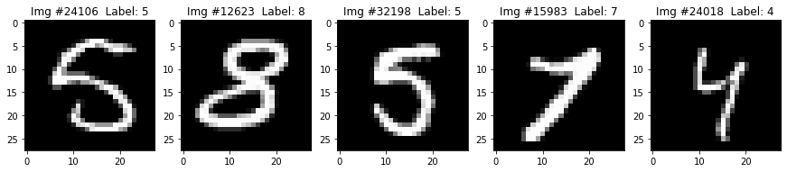

```python
train_dataset = datasets.MNIST(root='./data',train=True, transform=transforms.ToTensor(), download=True)
test_dataset = datasets.MNIST(root='./data',train=False, transform=transforms.ToTensor() ,download=True)

fig, ax = plt.subplots(1,5)
fig.set_size_inches(15, 3)

ids = np.random.randint(low=0, high=len(train_dataset), size=5)

for i, n in enumerate(ids):
    img = train_dataset[n][0].numpy().reshape(28,28)
    ax[i].imshow(img, cmap='gray')
    ax[i].set_title(f"Img #{n}  Label: {train_dataset[n][1]}")
plt.show()
```

```python
BATCH_SIZE = 20

train_loader =  torch.utils.data.DataLoader(dataset=train_dataset,
                                            batch_size=BATCH_SIZE,
                                            shuffle=True)

test_loader =  torch.utils.data.DataLoader(dataset=test_dataset,
                                           batch_size=BATCH_SIZE,
                                           shuffle=False)

for i, (x,y) in enumerate(train_loader):
    print("x.shape:", x.shape, "y.shape:", y.shape)

    i+=1
    if (i==3):
        print("Breaking the loop...")
        break
```

```
x.shape: torch.Size([20, 1, 28, 28]) y.shape: torch.Size([20])
x.shape: torch.Size([20, 1, 28, 28]) y.shape: torch.Size([20])
x.shape: torch.Size([20, 1, 28, 28]) y.shape: torch.Size([20])
Breaking the loop...
```

## Benchmark Numpy Solution

```python
def train_numpy_model(train_loader, epoch, lr):
    # Initialize weights (Normal Xavier Initialization)
    w1 = np.random.normal(0,1,(784, 64)) * np.sqrt(2/(784+64))
    w2 = np.random.normal(0,1,(64, 10)) * np.sqrt(2/(64+10))

    loss_history = []
    acc_history = []
    for e in range(epoch):
        loss_epoch = []
        acc_epoch = []
        for x,y in train_loader:
            x_ = x.reshape((x.shape[0], -1)).numpy()
            y_ = one_hot(y)

            # forward
            a1 = x_ @ w1     # a1.shape = (20,64)
            l1 = sigmoid(a1) # l1.shape = (20,64)
            a2 = l1 @ w2     # a2.shape = (20,10)
            l2 = softmax(a2) # l2.shape = (20,10)

            # loss & accuracy
            loss = mse_loss(y_, l2) # l2 = y_pred
            loss_epoch.append(loss)
            acc = np.mean(np.argmax(l2, axis=1) == np.argmax(y_, axis=1))
            acc_epoch.append(acc)

            # backward
            l2_grad = mse_loss_derivative(y_, l2) # (20,10)
            a2_grad = np.sum(softmax_derivative(l2) * l2_grad.reshape(l2_grad.shape[0],10,1), axis=1) # (20,10)
            w2_grad = l1.T @ a2_grad # (64,10)
            l1_grad = a2_grad @ w2.T
            w1_grad = x_.T @ (sigmoid_derivative(l1) * l1_grad) # (784,20) @ (20,64)

            # update
            w2 -= lr*w2_grad
            w1 -= lr*w1_grad

        loss_history.extend(loss_epoch)
        acc_history.extend(acc_epoch)
        print("Epoch:", e+1, "Loss:", np.mean(loss_epoch), "Accuracy:", np.mean(acc_epoch))

    return w1, w2, loss_history, acc_history

def test_numpy_model(test_loader, w1, w2):
    test_acc = []
    test_loss = []
    for x,y in test_loader:
        x_ = x.reshape((x.shape[0], -1)).numpy()
        y_ = one_hot(y)

        # forward
        a1 = x_ @ w1     # a1.shape = (20,64)
        l1 = sigmoid(a1) # l1.shape = (20,64)
        a2 = l1 @ w2     # a2.shape = (20,10)
        l2 = softmax(a2) # l2.shape = (20,10)

        # loss & accuracy
        loss = mse_loss(y_, l2) # l2 = y_pred
        acc = np.mean(np.argmax(l2, axis=1) == np.argmax(y_, axis=1))
        test_loss.append(loss)
        test_acc.append(acc)

    return test_loss, test_acc, np.mean(test_loss), np.mean(test_acc)
```

```
Epoch: 1 Loss: 0.08714025205200562 Accuracy: 0.29455
Epoch: 2 Loss: 0.07448835975520639 Accuracy: 0.4588333333333333
Epoch: 3 Loss: 0.06060484433883361 Accuracy: 0.6133000000000001
Epoch: 4 Loss: 0.04920049734002218 Accuracy: 0.7124166666666667
Epoch: 5 Loss: 0.04067795527982311 Accuracy: 0.777
Epoch: 6 Loss: 0.0342654121572371 Accuracy: 0.8260833333333333
Epoch: 7 Loss: 0.02952780943235888 Accuracy: 0.8540333333333333
Epoch: 8 Loss: 0.02615912739241622 Accuracy: 0.8668
Epoch: 9 Loss: 0.02377947248472376 Accuracy: 0.8749166666666667
Epoch: 10 Loss: 0.0220483097213976 Accuracy: 0.881
Epoch: 11 Loss: 0.020744154388003488 Accuracy: 0.8847666666666667
Epoch: 12 Loss: 0.019727971218432904 Accuracy: 0.8877333333333333
Epoch: 13 Loss: 0.018905612664478374 Accuracy: 0.8911499999999999
Epoch: 14 Loss: 0.018235607745329323 Accuracy: 0.8936166666666666
Epoch: 15 Loss: 0.017663128615962805 Accuracy: 0.8954
Elapsed Time for Python/Numpy implementation: 127.85 seconds
Test Acc: 0.9022 Test Loss: 0.016503536256247887
```

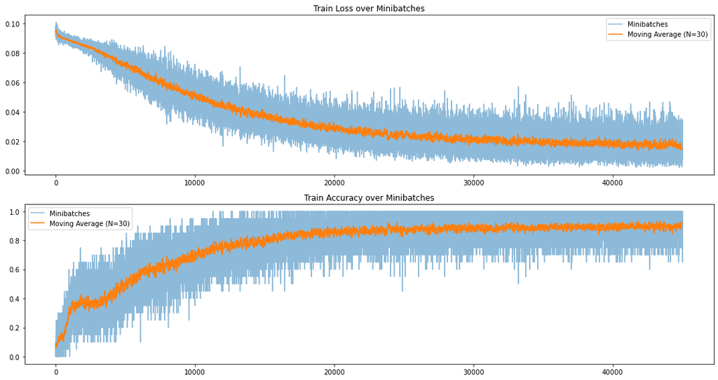

```python
cache_dataloader(train_loader)

start_time = time.time()
w1, w2, train_loss_history_np, train_acc_history_np = train_numpy_model(train_loader, epoch = 15, lr = 0.05)
end_time = time.time()
time_numpy_implementation = end_time - start_time
print("Elapsed Time for Python/Numpy implementation:", round(time_numpy_implementation, 2), "seconds")

test_loss_np, test_acc_np, avg_test_loss_np, avg_test_acc_np = test_numpy_model(test_loader, w1, w2)
print("Test Acc:", avg_test_acc_np, "Test Loss:", avg_test_loss_np)

plot_results(train_loss_history_np, train_acc_history_np)
```

## Benchmark PyTorch Solution

```python
class Model(nn.Module):
    def __init__(self):
      super(Model, self).__init__()
      self.flatten = nn.Flatten()
      self.fc1 = nn.Linear(784, 64, bias=False) # no bias because assignment sheet says so
      self.fc2 = nn.Linear(64, 10, bias=False)
      self.softmax = nn.Softmax(dim=1)

    def forward(self, x):
        x = self.flatten(x)
        x = self.fc1(x)
        x = self.fc2(x)
        return self.softmax(x)

model = Model()
print(model)
```

```
Model(
  (flatten): Flatten(start_dim=1, end_dim=-1)
  (fc1): Linear(in_features=784, out_features=64, bias=False)
  (fc2): Linear(in_features=64, out_features=10, bias=False)
  (softmax): Softmax(dim=1)
)
```

```python
def train_pytorch_model(train_loader, epoch, lr):
    model = Model()
    loss_f = torch.nn.MSELoss()
    optimizer = torch.optim.SGD(model.parameters(), lr=lr)

    loss_history = []
    acc_history = []
    for e in range(epoch):
        loss_epoch = []
        acc_epoch = []
        for x,y in train_loader:
            y_pred = model(x)
            y_ = one_hot_torch(y)
            loss = loss_f(y_pred, y_)
            loss.backward()
            optimizer.step()
            optimizer.zero_grad()

            loss_epoch.append(loss.detach().numpy())
            acc = np.mean(np.argmax(y_pred.detach().numpy(), axis=1) == np.argmax(y_.detach().numpy(), axis=1))
            acc_epoch.append(acc)

        loss_history.extend(loss_epoch)
        acc_history.extend(acc_epoch)
        print("Epoch:", e+1, "Loss:", np.mean(loss_epoch), "Accuracy:", np.mean(acc_epoch))

    return model, loss_history, acc_history

def test_pytorch_model(test_loader, model):
    loss_f = torch.nn.MSELoss()
    test_acc = []
    test_loss = []

    with torch.no_grad():
        for x,y in test_loader:
            y_pred = model(x)
            y_ = one_hot_torch(y)
            loss = loss_f(y_pred, y_)

            test_loss.append(loss.detach().numpy())
            acc = np.mean(np.argmax(y_pred.detach().numpy(), axis=1) == np.argmax(y_.detach().numpy(), axis=1))
            test_acc.append(acc)

    return test_loss, test_acc, np.mean(test_loss), np.mean(test_acc)
```

```
Epoch: 1 Loss: 0.06578068 Accuracy: 0.6008166666666668
Epoch: 2 Loss: 0.028254997 Accuracy: 0.8405666666666666
Epoch: 3 Loss: 0.019987553 Accuracy: 0.8815833333333334
Epoch: 4 Loss: 0.017387027 Accuracy: 0.8925166666666667
Epoch: 5 Loss: 0.016055357 Accuracy: 0.8990833333333333
Epoch: 6 Loss: 0.01522273 Accuracy: 0.9038999999999999
Epoch: 7 Loss: 0.014639524 Accuracy: 0.9062833333333331
Epoch: 8 Loss: 0.014197914 Accuracy: 0.9091666666666667
Epoch: 9 Loss: 0.013838698 Accuracy: 0.9113333333333333
Epoch: 10 Loss: 0.013557264 Accuracy: 0.9131499999999999
Epoch: 11 Loss: 0.013314967 Accuracy: 0.9147333333333333
Epoch: 12 Loss: 0.013109698 Accuracy: 0.9158333333333334
Epoch: 13 Loss: 0.01292756 Accuracy: 0.9170833333333334
Epoch: 14 Loss: 0.012766925 Accuracy: 0.91775
Epoch: 15 Loss: 0.012626409 Accuracy: 0.9190333333333331
Elapsed Time for PyTorch implementation: 132.48238825798035
Test Acc: 0.9207000000000001 Test Loss: 0.012166854
```

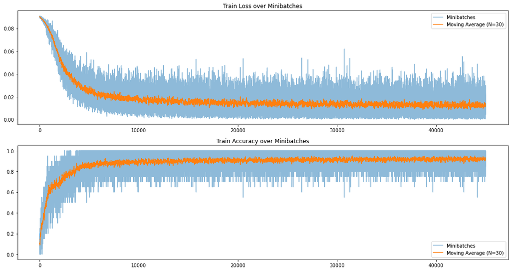

```python
cache_dataloader(train_loader)

start_time = time.time()
model, train_loss_history_torch, train_acc_history_torch = train_pytorch_model(train_loader, epoch = 15, lr = 0.05)
end_time = time.time()
time_pytorch_implementation = end_time - start_time
print("Elapsed Time for PyTorch implementation:", time_pytorch_implementation)

test_loss_torch, test_acc_torch, avg_test_loss_torch, avg_test_acc_torch = test_pytorch_model(test_loader, model)
print("Test Acc:", avg_test_acc_torch, "Test Loss:", avg_test_loss_torch)

plot_results(train_loss_history_torch, train_acc_history_torch)
```

## Results & Thoughts

My implementation is not perfect. But it is still better than pure Python implementation and very close to the PyTorch implementation run-times. For this run Numpy implementation was faster but sometimes with different library versions PyTorch becomes faster. Accuracies also change between different versions of Numpy/PyTorch or between different runs.

On the other hand, PyTorch holds the advantage of being able to use GPU's for computation. Maybe the next challenge would be about training a CNN model with PyTorch and Jax (Similar to Numpy but with many features like Autograd and CUDA support).

Also maybe you noticed the difference convergence of train loss between PyTorch and Numpy implementations. I believe that the difference between weight initialization methods are causing this phenomenon. Here I have used Normal Xavier Initialization. I am leaving the finding the default PyTorch weight initialization for Linear layers to the reader. Thank you for reading :)

```python
time_diff = time_pytorch_implementation - time_numpy_implementation
max_time = max(time_pytorch_implementation, time_numpy_implementation)

if (time_diff > 0):
    print("Numpy implementation is faster than PyTorch about", time_diff, "seconds...")
    print("About", "%" + str(100*time_diff/max_time), "faster!")
else:
    print("Numpy implementation is slower than PyTorch about", -time_diff, "seconds...")
    print("About", "%" + str(100*time_diff/max_time), "slower!")

print("Numpy implementation test set accuracy:", avg_test_acc_np)
print("PyTorch implementation test set accuracy:", avg_test_acc_torch)
```

```
Numpy implementation is faster than PyTorch about 4.631637334823608 seconds...
About %3.496040036509994 faster!
Numpy implementation test set accuracy: 0.9022
PyTorch implementation test set accuracy: 0.9207000000000001
```